# Week 3

Problem 1. (a) The code outputs that the condition number grows approximately as $e^{1.1645n}$

(b) It still grew exponentially when I changed `xv` to be `linspace(-1, 1, n)` or `rand(1, n)` (arithmetic progression from $[-1, 1]$ and random numbers between $[0, 1]$ respectively).

(c) The condition number of the DFT matrices are all $1$ (they're within $10^{-10}$ of $1$, so I assume they are only not equal to $1$ due to computer error).

(d) I've attached two images for the Vandermonde and Hilbert condition numbers. The Vandermonde matrices are taken with `xv = linspace(0, 1, n)` because the entries in Hilbert matrices are always between $0$ and $1$. The Vandermonde matrices are not as ill-conditioned as the Hilbert matrices.

(e) Yes, I ran into that in problem 2 so for part (d) I restricted $n$ to be between $1$ and $10$.

Vandermonde:

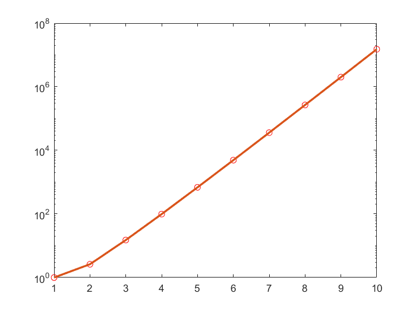

Hilbert:

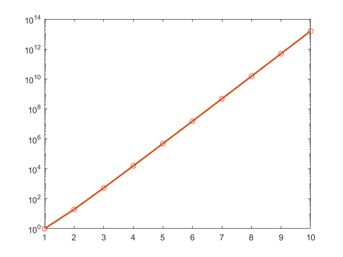

Problem 2. (a) Code below (in Python)

```python
# example for n=6

import numpy as np
n = 6
print("n =", n)
H = np.array([[1/(i+j - 1) for i in range(1, n+1)] for j in range(1, n+1)])
print("H =", H)

x = np.sqrt([i for i in range(1, n+1)])
print("x_ex =", x)

b = H @ x
print("b =", b)

# Get the machine "exact" solution
machine_x = np.linalg.solve(H, b)
print("x =", machine_x)

print("||x - x_ex|| =", np.sum((x - machine_x)**2))
```

```
n = 6
H = [[1.    0.5   0.333 0.25  0.2   0.167]
 [0.5   0.333 0.25  0.2   0.167 0.143]
 [0.333 0.25  0.2   0.167 0.143 0.125]
 [0.25  0.2   0.167 0.143 0.125 0.111]
 [0.2   0.167 0.143 0.125 0.111 0.1  ]
 [0.167 0.143 0.125 0.111 0.1   0.091]]
x_ex = [1.    1.414 1.732 2.    2.236 2.449]
b = [3.64  2.527 1.992 1.659 1.427 1.254]
x = [1.    1.414 1.732 2.    2.236 2.449]
||x - x_ex|| = 8.372801340874966e-19
```

Note how small the error is. Here I draw a graph of the error as $n$ ranges from $1$ to $10$:

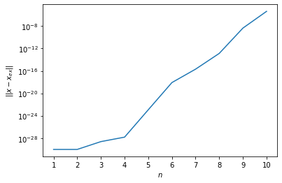

```python
import matplotlib.pyplot as plt

errors = []

mi, ma = 1, 10
ns = np.array(range(mi, ma+1))
for n in ns:
    H = np.array([[1/(i+j - 1) for i in range(1, n+1)] for j in range(1, n+1)])
    x = np.sqrt([i for i in range(1, n+1)])
    b = H @ x
    machine_x = np.linalg.solve(H, b)
    errors.append(np.sum((x - machine_x)**2))

plt.plot(ns, np.maximum(errors, 1e-30)) # clamp the min to 1e-30 so we can see it on the graph
plt.yscale("log")
plt.ylabel("$||x - x_{ex}||$")
plt.xticks(ns)
plt.xlabel("$n$")
plt.show()
```

The error grows exponentially up until $n\approx 10$, where it probably starts to taper due to truncation errors in the "exact" solution vector $x$. Let's check out the relative growth, $$r = \frac{||x_{n+1} - x_{ex, n+1}||}{||x_n - x_{ex, n}||}$$ Code and plot below:

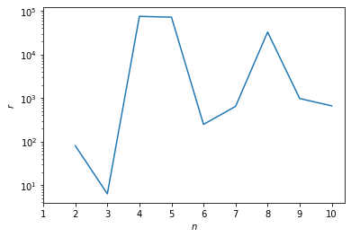

```python
errors = []

mi, ma = 1, 10
ns = np.array(range(mi, ma+1))
for n in range(mi, ma + 2):
    H = np.array([[1/(i+j - 1) for i in range(1, n+1)] for j in range(1, n+1)])
    x = np.sqrt([i for i in range(1, n+1)])
    b = H @ x
    machine_x = np.linalg.solve(H, b)
    errors.append(np.sum((x - machine_x)**2))

rs = [errors[n]/errors[n-1] for n in ns]
plt.plot(ns, rs)
plt.yscale("log")
plt.ylabel("$r$")
plt.xticks(ns)
plt.xlabel("$n$")
plt.show()
```

You can see that the error rate fluctuates a lot.

(b) Now we try adding $0.1^n$ to the last entry in $b$ and see how it effects the error. Here's a graph of the error, again for $n$ from $1$ to $10$.

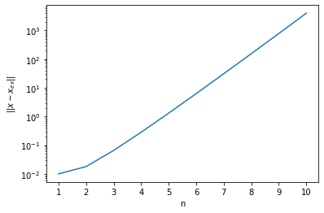

```python
errors = []

mi, ma = 1, 10
ns = np.array(range(mi, ma+1))
for n in ns:
    H = np.array([[1/(i+j - 1) for i in range(1, n+1)] for j in range(1, n+1)])
    x = np.sqrt([i for i in range(1, n+1)])
    b = H @ x
    b[-1] += np.power(0.1, n)
    machine_x = np.linalg.solve(H, b)
    errors.append(np.sum((x - machine_x)**2))

plt.plot(ns, np.maximum(errors, 1e-30)) # clamp the min to 1e-30 so we can see it on the graph
plt.yscale("log")
plt.ylabel("$||x - x_{ex}||$")
plt.xticks(ns)
plt.xlabel("n")
plt.show()
```

Again, let's look at the ratio of errors (using the formula I defined above):

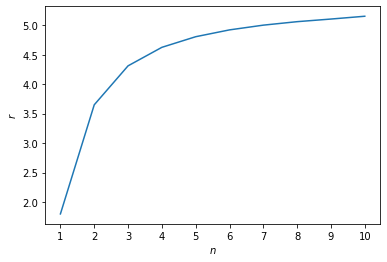

```python
errors = []

mi, ma = 1, 10
ns = np.array(range(mi, ma+1))
for n in range(mi, ma + 2):
    H = np.array([[1/(i+j - 1) for i in range(1, n+1)] for j in range(1, n+1)])
    x = np.sqrt([i for i in range(1, n+1)])
    b = H @ x
    b[-1] += np.power(0.1, n)
    machine_x = np.linalg.solve(H, b)
    errors.append(np.sum((x - machine_x)**2))

rs = [errors[n]/errors[n-1] for n in ns]
plt.plot(ns, rs)
plt.ylabel("$r$")
plt.xticks(ns)
plt.xlabel("$n$")
plt.show()
```

The relative solution error $||x-x_{ex}||$ is essentially staying the same as $n$ increases. It does start out closer to $2$, but it quicker gets to around $5$ and stays there.

(c) Now we do the same as in part (b), except we try modifying the Hilbert matrix slightly (subtracting $0.1^n$ to $H_{nn}$). Here's the error plot:

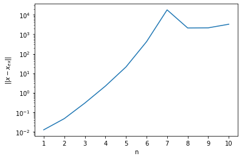

```python
errors = []

mi, ma = 1, 10
ns = np.array(range(mi, ma+1))
for n in ns:
    H = np.array([[1/(i+j - 1) for i in range(1, n+1)] for j in range(1, n+1)])
    x = np.sqrt([i for i in range(1, n+1)])
    b = H @ x
    H[-1, -1] -= np.power(0.1, n)
    machine_x = np.linalg.solve(H, b)
    errors.append(np.sum((x - machine_x)**2))

plt.plot(ns, np.maximum(errors, 1e-30)) # clamp the min to 1e-30 so we can see it on the graph
plt.yscale("log")
plt.ylabel("$||x - x_{ex}||$")
plt.xticks(ns)
plt.xlabel("n")
plt.show()
```

And now for the error ratio:

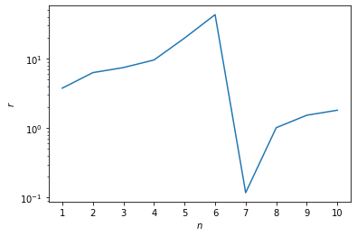

```
Ratios: [3.765495867768624, 6.305532421177744, 7.455211993660523, 9.590376800396776, 19.8253929334514, 43.18508309922848, 0.1174197890052761, 1.0150602962518298, 1.5341676424063466, 1.811613971087938]
```

```python
errors = []

mi, ma = 1, 10
ns = np.array(range(mi, ma+1))
for n in range(mi, ma + 2):
    H = np.array([[1/(i+j - 1) for i in range(1, n+1)] for j in range(1, n+1)])
    x = np.sqrt([i for i in range(1, n+1)])
    b = H @ x
    H[-1, -1] -= np.power(0.1, n)
    machine_x = np.linalg.solve(H, b)
    errors.append(np.sum((x - machine_x)**2))

rs = [errors[n]/errors[n-1] for n in ns]
plt.plot(ns, rs)
plt.yscale("log")
plt.ylabel("$r$")
plt.xticks(ns)
plt.xlabel("$n$")
plt.show()
print("Ratios:",rs)
```

The ratio is always increasing except between $n=6$ and $n=7$.

Problem 3. (a) So, I could do this by hand but it gets pretty ugly. Instead I'll just write some code to find the four orthogonal polynomials:

```python
import sympy as sp
from IPython.display import display, Latex

x = sp.Symbol("x")
def norm(p1, p2):
    p = sp.expand(p1 * p2 * (x ** 0.5))
    return sp.integrate(p, (x, 0, 1))

vs = [x**i for i in range(4)]
us = [1/norm(1,1)**0.5]

# Gram-Schmidt process:
for v in vs[1:]:
    u_next = v - sum(norm(u, v)/norm(u,u)*u for u in us)
    u_next /= norm(u_next, u_next)**0.5
    us.append(u_next)

print("Orthogonal polynomials (I actually made them orthonormal, \
because why not?):")
display(Latex(f"$${sp.latex(us)}$$"))

# Print out the norms of
mat = [[norm(u1, u2) if abs(norm(u1, u2)) > 1e-10 else 0 for u1 in us] for u2 in us]
mat = np.array([[float('{:.3f}'.format(value)) for value in row] for row in mat])
print("\n<u_i, u_j> matrix:")
print(mat)
print("\n\n\nShould be about 0 everywhere except along the diagonal.")
```

```
Orthogonal polynomials (I actually made them orthonormal, because why not?):
```

$$\left[ 1.22474487139159, \ 4.67707173346743 x - 2.80624304008046, \ 18.4685120543045 x^{2} - 20.5205689492272 x + 4.39726477483439, \ 73.4290553655637 x^{3} - 118.616166359759 x^{2} + 53.9164392544378 x - 5.99071547271559\right]$$

```
<u_i, u_j> matrix:
[[1. 0. 0. 0.]
 [0. 1. 0. 0.]
 [0. 0. 1. 0.]
 [0. 0. 0. 1.]]



Should be about 0 everywhere except along the diagonal.
```

(b) Now for the best cubic function to approximate $cos(\pi x)$ over $[0, 1]$. I wrote some code for it:

```python
f = sp.cos(sp.pi*x)
a = sp.expand(sum(u*sp.Integral(f * u * x**0.5, (x, 0, 1)).evalf()/norm(u, u) for u in us))
print("Best approximation:")
a
```

```
Best approximation:
```

$\displaystyle 4.51370823431324 x^{3} - 6.77413314973448 x^{2} + 0.280793370110941 x + 0.98910417522293$

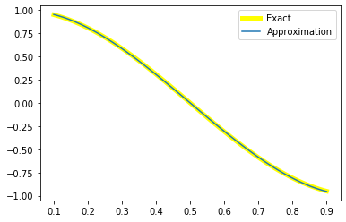

```
(I made the exact line wider so you can see they fit almost exactly.)
```

```python
# Now we graph it

xs = np.linspace(0.1, 0.9, 101)
exact = sp.lambdify(x, f, "numpy")(xs)
approx = sp.lambdify(x, a, "numpy")(xs)

plt.plot(xs, exact, label="Exact", linewidth=5, color="yellow")
plt.plot(xs, approx, label="Approximation")
plt.legend()
plt.show()
print("(I made the exact line wider so you can see they fit almost exactly.)")
```

# Problems from the textbook

5.7. The line is of the form $ax + b$. The least squares line will then minimize $$\int\limits_{0}^{1} (f(x) - (ax + b))^2 dx$$ To minimize this we can use Lagrange multipliers. Just kidding, we're going to take the partial derivatives with respect to $a$ and $b$, and the minimum will occur when those are equal to zero. The partial derivative with respect to $a$ gives the equation \begin{align*} 0 &= \frac{\partial}{\partial a} \int\limits_{0}^{1} (f(x) - (ax + b))^2 dx\\ &= \int\limits_{0}^{1} 2[f(x) - (ax + b)](-x) dx\\ &= \int\limits_{0}^{1} 2[-x^{1.5} + ax^2 + bx]dx\\ &= -\frac45 + \frac{2a}{3} + b \end{align*} The partial derivative with respect to $b$ gives \begin{align*} 0 &= \frac{\partial}{\partial a} \int\limits_{0}^{1} (f(x) - (ax + b))^2 dx\\ &= \int\limits_{0}^{1} 2[f(x) - (ax + b)] dx\\ &=\int\limits_{0}^{1} 2[x^{0.5} - ax - b] dx\\ &= \frac43 - a - 2b \end{align*}

Solving for $a$ and $b$ we have $$a=\frac{4}{5}, b=\frac{4}{15}$$ so the least squares line is $$f(x) \approx \boxed{\frac{4}{5}x + \frac{4}{15}}.$$ Here's a graph of it:

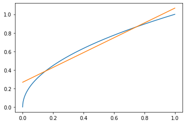

```python
import matplotlib.pyplot as plt
import numpy as np
x = np.linspace(0, 1, 1000)
y_exact = x**0.5
y_approx = 4/5*x + 4/15
plt.plot(x, y_exact)
plt.plot(x, y_approx)
```

5.13. This time I'll use some linear algebra. Let $M$ be a $5\times 3$ matrix so that it's first column has entries $m_{i1} = 1$, it's second column has entries $m_{i2} = x_i$, and it's last column has entries $m_{i3} = y_i$, where $(x_i, y_i, z_i)$ are the five points given. Also, let $z = [z_i]$ be the column vector with entries $z_i$. We want to find the vector $a = [a_0\ a_1\ a_2]$ that minimizes $$||Ma - z||$$ A well known formula gives $$a = (M^{T}M)^{-1}M^{T}z$$ I wrote some code to calculate this:

```python
M = np.array([[1, 0, 0], [1, 0, 1], [1, 1, 0], [1, 0, -1], [1, -1, 0]])
z = np.array([1.1, 1.9, 2.2, 0.0, 0.1])
a = np.linalg.inv(M.T @ M) @ M.T @ z
print("a =",a)
```

```
a = [1.06 1.05 0.95]
```

So the least squares planar approximation is $z = 1.06 + 1.05x + 0.95y.$ Here's a graph of it:

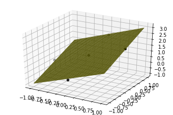

```python
from mpl_toolkits.mplot3d import Axes3D
fig = plt.figure()
ax = fig.add_subplot(111, projection='3d')
x = [0, 0, 1, 0, -1]
y = [0, 1, 0, -1, 0]
z = [1.1, 1.9, 2.2, 0.0, 0.1]
surf_x,surf_y = np.mgrid[-1:1:0.01, -1:1:0.01]
surf_z = 1.06 + 1.05*surf_x + 0.95*surf_y
ax.plot_surface(surf_x, surf_y, surf_z, color="yellow")
ax.scatter(x, y, z, color="black")
```

5.15. First to prove equation 5.16 in the textbook. We want to set the partial derivatives with respect to each $a_r$ equal to zero. Consider any such $a_k$. We have \begin{align*} \frac{\partial}{\partial a_k}\int\limits_{a}^{b}[f(x) - \sum_{r=0}^{n}a_r\psi_r(x)]^2\text{d}x &= 0\\ &\Longleftrightarrow\\ \int\limits_{a}^{b}2[f(x) - \sum_{r=0}^{n}a_r\psi_r(x)](-\psi_k(x))\text{d}x &=0\\ &\Longleftrightarrow\\ \int\limits_{a}^{b}2f(x)\psi_k(x)\text{d}x - \sum_{r=0}^{n}2a_r\int\limits_{a}^{b}\psi_k(x)\psi_r(x)\text{d}x &= 0 \end{align*} However for $r\ne k$ we have $$\int\limits_{a}^{b}\psi_k(x)\psi_r(x)\text{d}x = 0$$ so everything cancels in the summation except the $r=k term$. We're left with $$\int\limits_{a}^{b}2f(x)\psi_k(x)\text{d}x - 2a_k\int\limits_{a}^{b}\psi_k(x)^2\text{d}x$$ $$\Longleftrightarrow$$ $$\int\limits_{a}^{b}f(x)\psi_k(x)\text{d}x = a_k\int\limits_{a}^{b}\psi_k(x)^2\text{d}x$$ Which is equation $5.16$.

So we have \begin{align*} \int\limits_{a}^{b}[f(x) - \sum_{r=0}^{n}a_r\psi_r(x)]^2\text{d}x &=\\ \int\limits_{a}^{b}[f(x)]^2\text{d}x - 2\int\limits_{a}^{b}f(x)\sum_{r=0}^{n}a_r\psi_r(x)\text{d}x + \int\limits_{a}^{b}[\sum_{r=0}^{n}a_r\psi_r(x)]^2\text{d}x &= \end{align*}

If you expand out the term inside the last integral you get $$\sum_{r=0}^n(a_r\psi_r(x))^2 + 2\sum_{j\ne k}a_ja_k\psi_j(x)\psi_k(x)$$ Because $\psi_j$ and $\psi_k$ are orthogonal for $j\ne k$, when you take the integral these terms will become equal to $0$. Now look at the second integral. From equation $5.16$ we have $$\int\limits_{a}^{b}f(x)\psi_r(x)\text{d}x = \int\limits_{a}^{b}a_r\psi_r(x)^2\text{d}x$$ So $$\int\limits_{a}^{b}f(x)\sum_{r=0}^{n}a_r\psi_r(x)\text{d}x = \int\limits_{a}^{b}\sum_{r=0}^{n}a_r^2\psi_r(x)^2\text{d}x$$

Now going back to the whole equation, we have that \begin{align*} \int\limits_{a}^{b}[f(x)]^2\text{d}x - 2\int\limits_{a}^{b}f(x)\sum_{r=0}^{n}a_r\psi_r(x)\text{d}x + \int\limits_{a}^{b}[\sum_{r=0}^{n}a_r\psi_r(x)]^2\text{d}x &=\\ \int\limits_{a}^{b}[f(x)]^2\text{d}x - 2\int\limits_{a}^{b}\sum_{r=0}^{n}a_r^2\psi_r(x)^2\text{d}x + \int\limits_{a}^{b}\sum_{r=0}^{n}a_r^2\psi_r(x)^2\text{d}x &=\\ \int\limits_{a}^{b}[f(x)]^2\text{d}x - \int\limits_{a}^{b}\sum_{r=0}^{n}a_r^2\psi_r(x)^2\text{d}x &=\\ \int\limits_{a}^{b}[f(x)]^2\text{d}x - \sum_{r=0}^{n}a_r^2\int\limits_{a}^{b}\psi_r(x)^2\text{d}x &= \end{align*} $\blacksquare$

5.17. The Fourier series coefficients are given by

$$a_0 = \frac{1}{\pi}[\int_{-\pi}^{0} -xdx + \int_{0}^{\pi} xdx] = \pi$$$$a_n = \frac{1}{\pi}[\int_{-\pi}^{0} -x\cos(nx)dx + \int_{0}^{\pi} x\cos(nx)dx] = \frac{2}{\pi}\int_{0}^{\pi} x\cos(nx)dx$$

Using integration by parts we have

$$\int x\cos(nx)dx = \frac{x\sin(nx)}{n} - \int\frac{sin(nx)}{n}dx = \frac{x\sin(nx)}{n} + \frac{\cos(nx)}{n^2}$$

so

$$a_n = \frac{2}{\pi}\cdot \frac{\cos(\pi n)-1}{n^2}$$

which is $0$ if $n$ is even and $-\frac{4}{\pi n^2}$ if $n$ is odd.

And the coefficients for $b_n$ are given with

$$b_n = \frac{1}{\pi}[\int_{-\pi}^{\pi}|x|\sin(nx)dx] = 0$$

as $|x|\sin(nx)dx$ is odd.

Putting it all together, we have

\begin{align*} |x| &= \frac{a_0}{2} + \sum a_n\cos(nx) + \sum b_n\sin(nx)\\ &= \frac{\pi}{2} - \sum_{n\text{ odd}} \frac{4}{\pi n^2}\cos(nx) \end{align*}

Here's a graph of it (up to $n=5$).

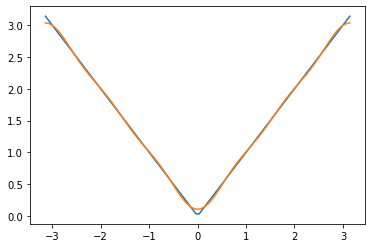

```python
x = np.linspace(-np.pi, np.pi, 100)
y_exact = abs(x)
N = 5
y_approx = np.pi/2 - sum(4/np.pi/n**2 * np.cos(n*x) for n in range(1, N+1, 2))

plt.plot(x, y_exact)
plt.plot(x, y_approx)
```

8? Problem 8 says, "For your curiousity: see handling bad outliers with least absolute deviation ... in absleastdev.m". However the link for `absleastdev.m` leads to a file in Dropbox called `rationalinterpolation.m`, which shows an example of polynomial vs rational interpolation.